# GSB 544 Lab 1

Author

Eddie Cagney

```python
import pandas as pd

q1_path = "C:/Users/Eddie/Documents/GSB 544/Data/q1data.csv"
q2_path = "C:/Users/Eddie/Documents/GSB 544/Data/q2data.csv"
q3_path = "C:/Users/Eddie/Documents/GSB 544/Data/q3data.csv"

q1_data = pd.read_csv(q1_path)
q2_data = pd.read_csv(q2_path)
q3_data = pd.read_csv(q3_path)
```

## Task 1

```python
q1_data_clean = q1_data.dropna(subset=["four_regions"])
q1_data_clean['four_regions'] = q1_data_clean['four_regions'].replace({'africa': 'Africa', 'americas': 'Americas', 'asia': 'Asia', 'europe': 'Europe'})
```

3. Creating Graph

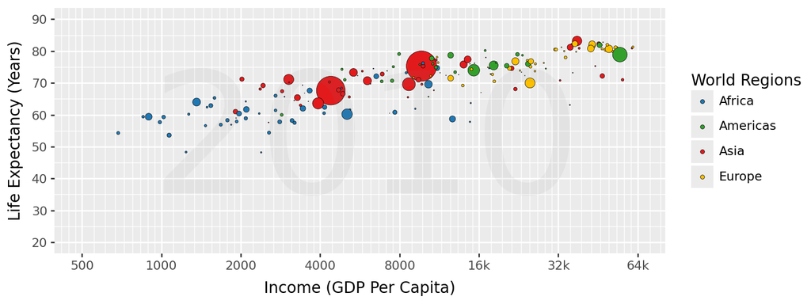

```python
from plotnine import *

region_colors = {
    "Asia": "#E31A1C",
    "Europe": "#FDBF00",
    "Americas": "#33A02C",
    "Africa": "#1F78B4",
}

income_breaks = [500, 1000, 2000, 4000, 8000, 16000, 32000, 64000]
income_labels = ['500','1000','2000','4000','8000','16k','32k','64k']

(ggplot(q1_data_clean,
aes(x = "income",
y = "life_exp",))
+ geom_point(aes(size = "population", fill = "four_regions"),
alpha = 1,
stroke=0.15,
color='black')
+ scale_fill_manual(values=region_colors)
+ scale_size_area(max_size= 12)
+ scale_x_log10(breaks = income_breaks, labels = income_labels, limits=(500, 64000))
+ scale_y_continuous(limits = (20, 90), breaks = [20,30,40,50,60,70,80,90])
+ guides(size=False)
+ labs(x="Income (GDP Per Capita)", y="Life Expectancy (Years)", fill="World Regions"
)
+ annotate('text', x=6000, y=50, label='2010', size=120, alpha=0.08, color='gray')
+ theme(figure_size= (8,3))
)
```

4. Another Geometry that could work to visualize this data is a 2d desnity chart. This would allow us to see the same patterns of Income and Life expectency while still allowing us to differentiate by world region. The disadvanage to this graph is that it is much less intuititve to what the data is saying about the population size, but it still gives us valid trends.

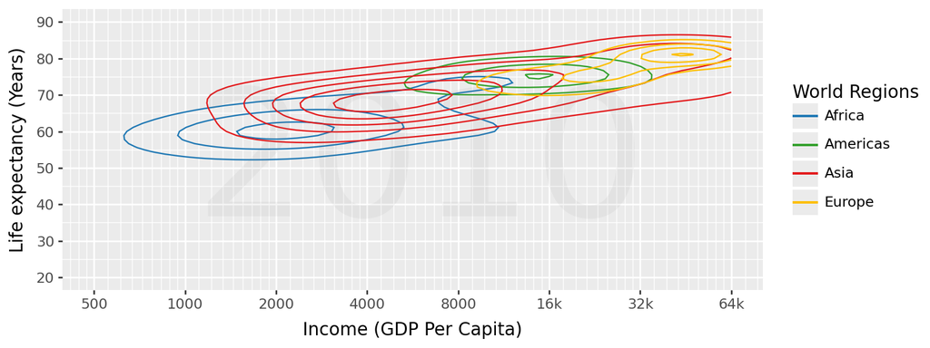

```python
(ggplot(q1_data_clean,
aes(x = "income",
y = "life_exp",
color = "four_regions"))
+ geom_density_2d(aes(weight="population"))
+ scale_color_manual(values=region_colors)
+ scale_x_log10(breaks = income_breaks, labels = income_labels, limits=(500, 64000))
+ scale_y_continuous(limits = (20, 90), breaks = [20,30,40,50,60,70,80,90])
+ guides(size=False)
+ labs(x="Income (GDP Per Capita)", y="Life expectancy (Years)", color="World Regions"
)
+ annotate('text', x=6000, y=50, label='2010', size=110, alpha=0.08, color='gray')
+ theme(figure_size= (8,3))
)
```

## Task 2

1. In this graph the aesthetics are mapped as exports on the x-axis, important on the y-axis. The geometry being used is geom_point (scatterplot) with the size of each point being determined by their given energy use.
2. Cleaning q2 Data

```python
q2_data_clean = q2_data.dropna(subset=["four_regions"])

def lame_values(val):
    if isinstance(val, str) and val.endswith("k"):
        return float(val[:-1]) * 1000
    return float(val)

q2_data_clean['energy'] = q2_data_clean['energy'].apply(lame_values)
q2_data_clean['four_regions'] = q2_data_clean['four_regions'].replace({'africa': 'Africa', 'americas': 'Americas', 'asia': 'Asia', 'europe': 'Europe'})
```

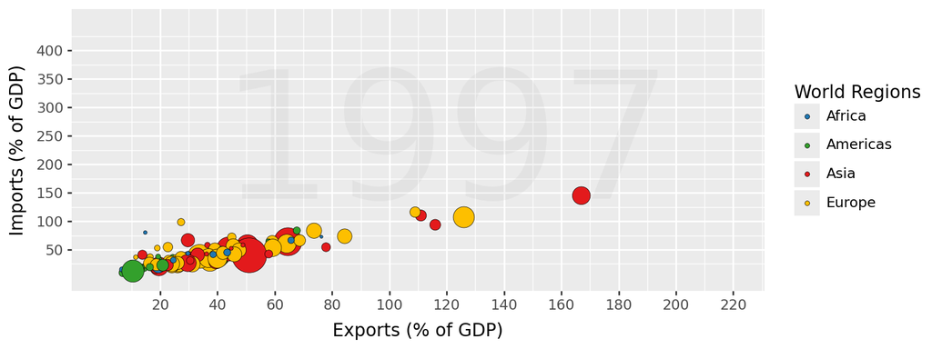

```python
(ggplot(q2_data_clean,
aes(x = "exports",
y = "imports"))
+ geom_point(aes(size = "energy", fill = "four_regions"),
alpha = 1,
stroke = 0.15,
color = 'black')
+ scale_fill_manual(values=region_colors)
+ scale_size_area(max_size=12)
+ scale_x_continuous(limits = [0, 220], breaks = [20,40,60,80,100,120,140,160, 180, 200, 220])
+ scale_y_continuous(limits = [0, 450], breaks = [50,100,150,200,250,300,350,400])
+ guides(size=False)
+ labs(x="Exports (% of GDP)", y="Imports (% of GDP)", fill="World Regions"
)
+ annotate('text', x=120, y=225, label='1997', size=110, alpha=0.08, color='gray')
+ theme(figure_size= (8,3))
)
```

4. Another geometry that could be used for this plot could be geom_jitter. We see a lot of overplotting in the bottom left of our graph and this could help with trend visualization. Although it doesn’t appear to be changing much in our plot.

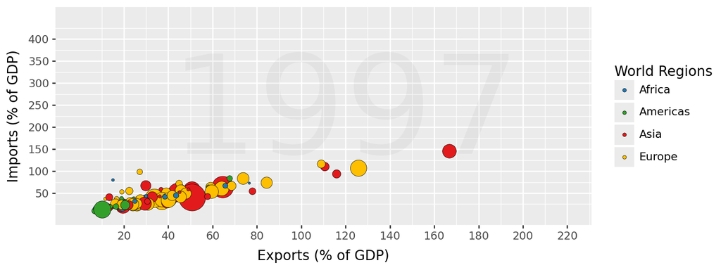

```python
(ggplot(q2_data_clean,
aes(x = "exports",
y = "imports"))
+ geom_jitter(aes(size = "energy", fill = "four_regions"),
alpha = 1,
stroke = 0.15,
color = 'black')
+ scale_fill_manual(values=region_colors)
+ scale_size_area(max_size=12)
+ scale_x_continuous(limits = [0, 220], breaks = [20,40,60,80,100,120,140,160, 180, 200, 220])
+ scale_y_continuous(limits = [0, 450], breaks = [50,100,150,200,250,300,350,400])
+ guides(size=False)
+ labs(x="Exports (% of GDP)", y="Imports (% of GDP)", fill="World Regions"
)
+ annotate('text', x=120, y=225, label='1997', size=110, alpha=0.08, color='gray')
+ theme(figure_size= (8,3))
)
```

## Task 3

1. In this plot, we are able to see that the aesthetics being mapped are individuals using the internet on the x-axis (internet_users) and GDP/Capita on the y-axis (gdp). The graph is colored/filled based off of four_regions and the size of the bubbles/points are based off of income.
2. Cleaning Data

```python
q3_data_clean = q3_data.dropna(subset=["four_regions"])

q3_data_clean['four_regions'] = q3_data_clean['four_regions'].replace({'africa': 'Africa', 'americas': 'Americas', 'asia': 'Asia', 'europe': 'Europe'})
```

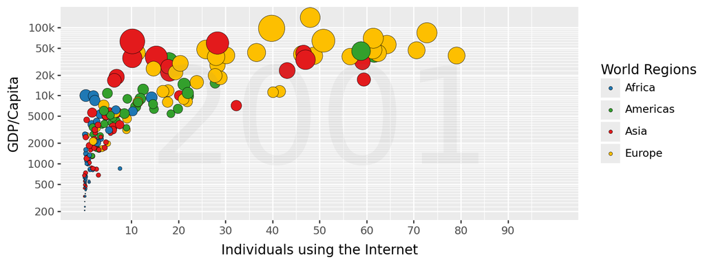

```python
(ggplot(q3_data_clean,
aes(x = "internet_users",
y = "gdp"))
+ geom_point(
  aes(size = "income", fill = 'four_regions'),
  alpha = 1,
  color = 'black',
  stroke = 0.15)
+ scale_fill_manual(values=region_colors)
+ scale_size_area(max_size=12)
+ scale_x_continuous(limits = [0, 100], breaks = [10,20,30,40,50,60,70,80,90])
+ scale_y_log10(limits = [0, 200000], breaks = [200,500,1000,2000,5000,10000,20000,50000,100000], labels = ['200', '500', '1000', '2000', '5000', '10k', '20k', '50k', '100k'])
+ guides(size=False)
+ labs(x="Individuals using the Internet", y="GDP/Capita", fill="World Regions"
)
+ annotate('text', x=50, y=3500, label='2001', size=110, alpha=0.08, color='gray')
+ theme(figure_size= (8,3))
)
```

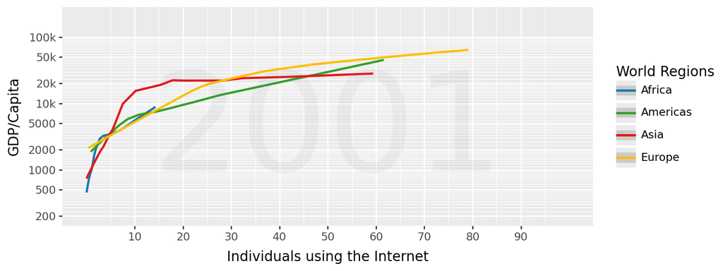

```python
(ggplot(q3_data_clean,
aes(x = "internet_users",
y = "gdp"))
+ geom_smooth(
  aes(color = "four_regions"))
+ scale_color_manual(values=region_colors)
+ scale_size_area(max_size=12)
+ scale_x_continuous(limits = [0, 100], breaks = [10,20,30,40,50,60,70,80,90])
+ scale_y_log10(limits = [200, 200000], breaks = [200,500,1000,2000,5000,10000,20000,50000,100000], labels = ['200', '500', '1000', '2000', '5000', '10k', '20k', '50k', '100k'])
+ guides(size=False)
+ labs(x="Individuals using the Internet", y="GDP/Capita", color="World Regions"
)
+ annotate('text', x=50, y=3500, label='2001', size=110, alpha=0.08, color='gray')
+ theme(figure_size= (8,3))
)
```

So, it would be best to use geom_point and geom_smooth together, this would give us all the same details from our original graph but also add another layer of linear trends (if any).

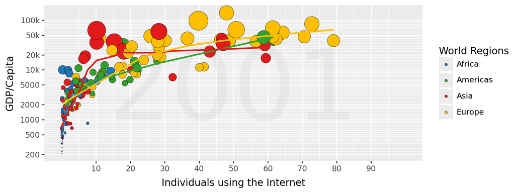

```python
(ggplot(q3_data_clean,
aes(x = "internet_users",
y = "gdp"))
+ geom_point(
  aes(size = "income", fill = 'four_regions'),
  alpha = 1,
  color = 'black',
  stroke = 0.15)
+ geom_smooth(aes(color = 'four_regions'), show_legend = False)
+ scale_fill_manual(values=region_colors)
+ scale_color_manual(values=region_colors)
+ scale_size_area(max_size=12)
+ scale_x_continuous(limits = [0, 100], breaks = [10,20,30,40,50,60,70,80,90])
+ scale_y_log10(limits = [0, 200000], breaks = [200,500,1000,2000,5000,10000,20000,50000,100000], labels = ['200', '500', '1000', '2000', '5000', '10k', '20k', '50k', '100k'])
+ guides(size=False)
+ labs(x="Individuals using the Internet", y="GDP/Capita", fill="World Regions"
)
+ annotate('text', x=50, y=3500, label='2001', size=110, alpha=0.08, color='gray')
+ theme(figure_size= (8,3))
)
```